# Optimal Treatment Analysis

## Outcome Variable

**Outcome Variable:** ever_wasted

## Predictor Variables

**Intervention Variable:** predexfd6

**Adjustment Set:**

- arm
- sex
- W_mage
- meducyrs
- feducyrs
- hhwealth_quart
- hfoodsec
- W_mhtcm
- vagbrth
- W_gagebrth
- W_birthwt
- W_birthlen
- W_nrooms
- W_nchldlt5
- month
- brthmon
- W_parity
- impfloor
- impsan
- safeh20
- delta_W_mage
- delta_meducyrs
- delta_feducyrs
- delta_hhwealth_quart
- delta_hfoodsec
- delta_W_mhtcm
- delta_vagbrth
- delta_W_gagebrth
- delta_W_birthwt
- delta_W_birthlen
- delta_W_nrooms
- delta_W_nchldlt5
- delta_month
- delta_brthmon
- delta_W_parity
- delta_impfloor
- delta_impsan
- delta_safeh20

## Stratifying Variables

The analysis was stratified on these variable(s):

- agecat
- studyid
- country

## Data Summary

| agecat | studyid | country | predexfd6 | ever_wasted | n_cell | n |
| --- | --- | --- | --- | --- | --- | --- |
| 0-24 months (no birth wast) | ki0047075b-MAL-ED | BANGLADESH | 1 | 0 | 89 | 238 |
| 0-24 months (no birth wast) | ki0047075b-MAL-ED | BANGLADESH | 1 | 1 | 36 | 238 |
| 0-24 months (no birth wast) | ki0047075b-MAL-ED | BANGLADESH | 0 | 0 | 92 | 238 |
| 0-24 months (no birth wast) | ki0047075b-MAL-ED | BANGLADESH | 0 | 1 | 21 | 238 |
| 0-24 months (no birth wast) | ki0047075b-MAL-ED | BRAZIL | 1 | 0 | 35 | 211 |
| 0-24 months (no birth wast) | ki0047075b-MAL-ED | BRAZIL | 1 | 1 | 0 | 211 |
| 0-24 months (no birth wast) | ki0047075b-MAL-ED | BRAZIL | 0 | 0 | 164 | 211 |
| 0-24 months (no birth wast) | ki0047075b-MAL-ED | BRAZIL | 0 | 1 | 12 | 211 |
| 0-24 months (no birth wast) | ki0047075b-MAL-ED | INDIA | 1 | 0 | 15 | 230 |
| 0-24 months (no birth wast) | ki0047075b-MAL-ED | INDIA | 1 | 1 | 4 | 230 |
| 0-24 months (no birth wast) | ki0047075b-MAL-ED | INDIA | 0 | 0 | 130 | 230 |
| 0-24 months (no birth wast) | ki0047075b-MAL-ED | INDIA | 0 | 1 | 81 | 230 |
| 0-24 months (no birth wast) | ki0047075b-MAL-ED | NEPAL | 1 | 0 | 26 | 235 |
| 0-24 months (no birth wast) | ki0047075b-MAL-ED | NEPAL | 1 | 1 | 3 | 235 |
| 0-24 months (no birth wast) | ki0047075b-MAL-ED | NEPAL | 0 | 0 | 165 | 235 |
| 0-24 months (no birth wast) | ki0047075b-MAL-ED | NEPAL | 0 | 1 | 41 | 235 |
| 0-24 months (no birth wast) | ki0047075b-MAL-ED | PERU | 1 | 0 | 110 | 270 |
| 0-24 months (no birth wast) | ki0047075b-MAL-ED | PERU | 1 | 1 | 4 | 270 |
| 0-24 months (no birth wast) | ki0047075b-MAL-ED | PERU | 0 | 0 | 142 | 270 |
| 0-24 months (no birth wast) | ki0047075b-MAL-ED | PERU | 0 | 1 | 14 | 270 |
| 0-24 months (no birth wast) | ki0047075b-MAL-ED | SOUTH AFRICA | 1 | 0 | 3 | 248 |
| 0-24 months (no birth wast) | ki0047075b-MAL-ED | SOUTH AFRICA | 1 | 1 | 0 | 248 |
| 0-24 months (no birth wast) | ki0047075b-MAL-ED | SOUTH AFRICA | 0 | 0 | 202 | 248 |
| 0-24 months (no birth wast) | ki0047075b-MAL-ED | SOUTH AFRICA | 0 | 1 | 43 | 248 |
| 0-24 months (no birth wast) | ki0047075b-MAL-ED | TANZANIA, UNITED REPUBLIC OF | 1 | 0 | 2 | 248 |
| 0-24 months (no birth wast) | ki0047075b-MAL-ED | TANZANIA, UNITED REPUBLIC OF | 1 | 1 | 0 | 248 |
| 0-24 months (no birth wast) | ki0047075b-MAL-ED | TANZANIA, UNITED REPUBLIC OF | 0 | 0 | 216 | 248 |
| 0-24 months (no birth wast) | ki0047075b-MAL-ED | TANZANIA, UNITED REPUBLIC OF | 0 | 1 | 30 | 248 |
| 0-24 months (no birth wast) | ki1000108-CMC-V-BCS-2002 | INDIA | 1 | 0 | 11 | 19 |
| 0-24 months (no birth wast) | ki1000108-CMC-V-BCS-2002 | INDIA | 1 | 1 | 8 | 19 |

[output cut: 186 more lines]

The following strata were considered:

- agecat: 0-24 months (no birth wast), studyid: ki0047075b-MAL-ED, country: BANGLADESH
- agecat: 0-24 months (no birth wast), studyid: ki0047075b-MAL-ED, country: BRAZIL
- agecat: 0-24 months (no birth wast), studyid: ki0047075b-MAL-ED, country: INDIA
- agecat: 0-24 months (no birth wast), studyid: ki0047075b-MAL-ED, country: NEPAL
- agecat: 0-24 months (no birth wast), studyid: ki0047075b-MAL-ED, country: PERU
- agecat: 0-24 months (no birth wast), studyid: ki0047075b-MAL-ED, country: SOUTH AFRICA
- agecat: 0-24 months (no birth wast), studyid: ki0047075b-MAL-ED, country: TANZANIA, UNITED REPUBLIC OF
- agecat: 0-24 months (no birth wast), studyid: ki1000108-CMC-V-BCS-2002, country: INDIA
- agecat: 0-24 months (no birth wast), studyid: ki1000108-IRC, country: INDIA
- agecat: 0-24 months (no birth wast), studyid: ki1000109-EE, country: PAKISTAN
- agecat: 0-24 months (no birth wast), studyid: ki1000304b-SAS-CompFeed, country: INDIA
- agecat: 0-24 months (no birth wast), studyid: ki1000304b-SAS-FoodSuppl, country: INDIA
- agecat: 0-24 months (no birth wast), studyid: ki1017093b-PROVIDE, country: BANGLADESH
- agecat: 0-24 months (no birth wast), studyid: ki1101329-Keneba, country: GAMBIA
- agecat: 0-24 months (no birth wast), studyid: ki1113344-GMS-Nepal, country: NEPAL
- agecat: 0-24 months (no birth wast), studyid: ki1148112-LCNI-5, country: MALAWI
- agecat: 0-24 months (no birth wast), studyid: kiGH5241-JiVitA-3, country: BANGLADESH
- agecat: 0-24 months (no birth wast), studyid: kiGH5241-JiVitA-4, country: BANGLADESH
- agecat: 0-6 months (no birth wast), studyid: ki0047075b-MAL-ED, country: BANGLADESH
- agecat: 0-6 months (no birth wast), studyid: ki0047075b-MAL-ED, country: BRAZIL
- agecat: 0-6 months (no birth wast), studyid: ki0047075b-MAL-ED, country: INDIA
- agecat: 0-6 months (no birth wast), studyid: ki0047075b-MAL-ED, country: NEPAL
- agecat: 0-6 months (no birth wast), studyid: ki0047075b-MAL-ED, country: PERU
- agecat: 0-6 months (no birth wast), studyid: ki0047075b-MAL-ED, country: SOUTH AFRICA
- agecat: 0-6 months (no birth wast), studyid: ki0047075b-MAL-ED, country: TANZANIA, UNITED REPUBLIC OF
- agecat: 0-6 months (no birth wast), studyid: ki1000108-CMC-V-BCS-2002, country: INDIA
- agecat: 0-6 months (no birth wast), studyid: ki1000108-IRC, country: INDIA
- agecat: 0-6 months (no birth wast), studyid: ki1000109-EE, country: PAKISTAN
- agecat: 0-6 months (no birth wast), studyid: ki1000304b-SAS-CompFeed, country: INDIA
- agecat: 0-6 months (no birth wast), studyid: ki1000304b-SAS-FoodSuppl, country: INDIA
- agecat: 0-6 months (no birth wast), studyid: ki1017093b-PROVIDE, country: BANGLADESH
- agecat: 0-6 months (no birth wast), studyid: ki1101329-Keneba, country: GAMBIA
- agecat: 0-6 months (no birth wast), studyid: ki1113344-GMS-Nepal, country: NEPAL
- agecat: 0-6 months (no birth wast), studyid: ki1148112-LCNI-5, country: MALAWI
- agecat: 0-6 months (no birth wast), studyid: kiGH5241-JiVitA-3, country: BANGLADESH
- agecat: 0-6 months (no birth wast), studyid: kiGH5241-JiVitA-4, country: BANGLADESH
- agecat: 6-24 months, studyid: ki0047075b-MAL-ED, country: BANGLADESH
- agecat: 6-24 months, studyid: ki0047075b-MAL-ED, country: BRAZIL
- agecat: 6-24 months, studyid: ki0047075b-MAL-ED, country: INDIA
- agecat: 6-24 months, studyid: ki0047075b-MAL-ED, country: NEPAL
- agecat: 6-24 months, studyid: ki0047075b-MAL-ED, country: PERU
- agecat: 6-24 months, studyid: ki0047075b-MAL-ED, country: SOUTH AFRICA
- agecat: 6-24 months, studyid: ki0047075b-MAL-ED, country: TANZANIA, UNITED REPUBLIC OF
- agecat: 6-24 months, studyid: ki1000108-CMC-V-BCS-2002, country: INDIA
- agecat: 6-24 months, studyid: ki1000108-IRC, country: INDIA
- agecat: 6-24 months, studyid: ki1000109-EE, country: PAKISTAN
- agecat: 6-24 months, studyid: ki1000304b-SAS-CompFeed, country: INDIA
- agecat: 6-24 months, studyid: ki1000304b-SAS-FoodSuppl, country: INDIA
- agecat: 6-24 months, studyid: ki1017093b-PROVIDE, country: BANGLADESH
- agecat: 6-24 months, studyid: ki1101329-Keneba, country: GAMBIA
- agecat: 6-24 months, studyid: ki1113344-GMS-Nepal, country: NEPAL
- agecat: 6-24 months, studyid: ki1148112-LCNI-5, country: MALAWI
- agecat: 6-24 months, studyid: kiGH5241-JiVitA-3, country: BANGLADESH
- agecat: 6-24 months, studyid: kiGH5241-JiVitA-4, country: BANGLADESH

### Dropped Strata

Some strata were dropped due to rare outcomes:

- agecat: 0-24 months (no birth wast), studyid: ki0047075b-MAL-ED, country: BRAZIL
- agecat: 0-24 months (no birth wast), studyid: ki0047075b-MAL-ED, country: INDIA
- agecat: 0-24 months (no birth wast), studyid: ki0047075b-MAL-ED, country: NEPAL
- agecat: 0-24 months (no birth wast), studyid: ki0047075b-MAL-ED, country: PERU
- agecat: 0-24 months (no birth wast), studyid: ki0047075b-MAL-ED, country: SOUTH AFRICA
- agecat: 0-24 months (no birth wast), studyid: ki0047075b-MAL-ED, country: TANZANIA, UNITED REPUBLIC OF
- agecat: 0-24 months (no birth wast), studyid: ki1000108-CMC-V-BCS-2002, country: INDIA
- agecat: 0-24 months (no birth wast), studyid: ki1000108-IRC, country: INDIA
- agecat: 0-24 months (no birth wast), studyid: ki1000304b-SAS-CompFeed, country: INDIA
- agecat: 0-24 months (no birth wast), studyid: ki1000304b-SAS-FoodSuppl, country: INDIA
- agecat: 0-6 months (no birth wast), studyid: ki0047075b-MAL-ED, country: BRAZIL
- agecat: 0-6 months (no birth wast), studyid: ki0047075b-MAL-ED, country: INDIA
- agecat: 0-6 months (no birth wast), studyid: ki0047075b-MAL-ED, country: NEPAL
- agecat: 0-6 months (no birth wast), studyid: ki0047075b-MAL-ED, country: PERU
- agecat: 0-6 months (no birth wast), studyid: ki0047075b-MAL-ED, country: SOUTH AFRICA
- agecat: 0-6 months (no birth wast), studyid: ki0047075b-MAL-ED, country: TANZANIA, UNITED REPUBLIC OF
- agecat: 0-6 months (no birth wast), studyid: ki1000108-CMC-V-BCS-2002, country: INDIA
- agecat: 0-6 months (no birth wast), studyid: ki1000108-IRC, country: INDIA
- agecat: 0-6 months (no birth wast), studyid: ki1000304b-SAS-CompFeed, country: INDIA
- agecat: 0-6 months (no birth wast), studyid: ki1000304b-SAS-FoodSuppl, country: INDIA
- agecat: 0-6 months (no birth wast), studyid: ki1148112-LCNI-5, country: MALAWI
- agecat: 6-24 months, studyid: ki0047075b-MAL-ED, country: BRAZIL
- agecat: 6-24 months, studyid: ki0047075b-MAL-ED, country: INDIA
- agecat: 6-24 months, studyid: ki0047075b-MAL-ED, country: NEPAL
- agecat: 6-24 months, studyid: ki0047075b-MAL-ED, country: PERU
- agecat: 6-24 months, studyid: ki0047075b-MAL-ED, country: SOUTH AFRICA
- agecat: 6-24 months, studyid: ki0047075b-MAL-ED, country: TANZANIA, UNITED REPUBLIC OF
- agecat: 6-24 months, studyid: ki1000108-CMC-V-BCS-2002, country: INDIA
- agecat: 6-24 months, studyid: ki1000108-IRC, country: INDIA
- agecat: 6-24 months, studyid: ki1000304b-SAS-CompFeed, country: INDIA
- agecat: 6-24 months, studyid: ki1000304b-SAS-FoodSuppl, country: INDIA

## Methods Detail

We’re interested in the causal parameters $E[Y_a]$ for all values of $a \in \mathcal{A}$. These parameters represent the mean outcome if, possibly contrary to fact, we intervened to set all units to have $A=a$. Under the randomization and positivity assumptions, these are identified by the statistical parameters $\psi_a=E_W[E_{Y|A,W}(Y|A=a,W)]$. In addition, we’re interested in the mean of $Y$, $E[Y]$ under no intervention (the observed mean). We will estimate these parameters by using SuperLearner to fit the relevant likelihood factors – $E_{Y|A,W}(Y|A=a,W)$ and $p(A=a|W)$, and then updating our likelihood fit using a joint TMLE.

For unadjusted analyses ($W=\{\}$), initial likelihoods were estimated using Lrnr_glm to estimate the simple $E(Y|A)$ and Lrnr_mean to estimate $p(A)$. For adjusted analyses, a small library containing Lrnr_glmnet, Lrnr_xgboost, and Lrnr_mean was used.

Having estimated these parameters, we will then use the delta method to estimate relative risks and attributable risks relative to a prespecified baseline level of $A$.

# Results Detail

## Results Plots

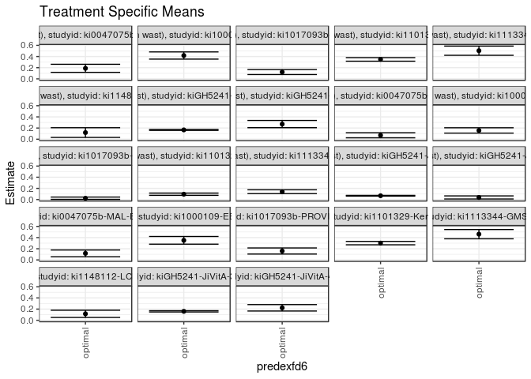

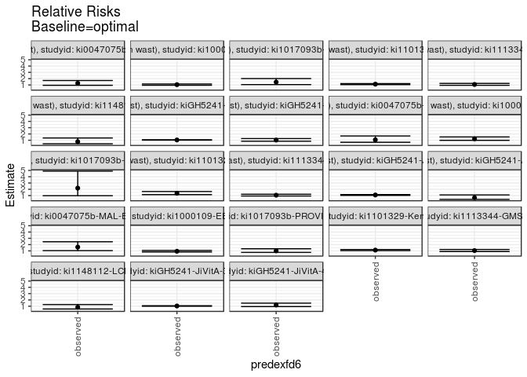

## Results Table

### Parameter: TSM

| agecat | studyid | country | intervention_level | baseline_level | estimate | ci_lower | ci_upper |
| --- | --- | --- | --- | --- | --- | --- | --- |
| 0-24 months (no birth wast) | ki0047075b-MAL-ED | BANGLADESH | optimal | NA | 0.1886693 | 0.1166742 | 0.2606643 |
| 0-24 months (no birth wast) | ki1000109-EE | PAKISTAN | optimal | NA | 0.4180220 | 0.3535630 | 0.4824811 |
| 0-24 months (no birth wast) | ki1017093b-PROVIDE | BANGLADESH | optimal | NA | 0.1218556 | 0.0769209 | 0.1667903 |
| 0-24 months (no birth wast) | ki1101329-Keneba | GAMBIA | optimal | NA | 0.3487466 | 0.3166713 | 0.3808219 |
| 0-24 months (no birth wast) | ki1113344-GMS-Nepal | NEPAL | optimal | NA | 0.5042524 | 0.4216671 | 0.5868376 |
| 0-24 months (no birth wast) | ki1148112-LCNI-5 | MALAWI | optimal | NA | 0.1189545 | 0.0322116 | 0.2056974 |
| 0-24 months (no birth wast) | kiGH5241-JiVitA-3 | BANGLADESH | optimal | NA | 0.1667814 | 0.1581658 | 0.1753971 |
| 0-24 months (no birth wast) | kiGH5241-JiVitA-4 | BANGLADESH | optimal | NA | 0.2709432 | 0.2063947 | 0.3354917 |
| 0-6 months (no birth wast) | ki0047075b-MAL-ED | BANGLADESH | optimal | NA | 0.0708453 | 0.0254746 | 0.1162160 |
| 0-6 months (no birth wast) | ki1000109-EE | PAKISTAN | optimal | NA | 0.1571514 | 0.1094629 | 0.2048399 |
| 0-6 months (no birth wast) | ki1017093b-PROVIDE | BANGLADESH | optimal | NA | 0.0241346 | 0.0031921 | 0.0450772 |
| 0-6 months (no birth wast) | ki1101329-Keneba | GAMBIA | optimal | NA | 0.0959966 | 0.0757356 | 0.1162576 |
| 0-6 months (no birth wast) | ki1113344-GMS-Nepal | NEPAL | optimal | NA | 0.1408147 | 0.1066297 | 0.1749996 |
| 0-6 months (no birth wast) | kiGH5241-JiVitA-3 | BANGLADESH | optimal | NA | 0.0687957 | 0.0623508 | 0.0752406 |
| 0-6 months (no birth wast) | kiGH5241-JiVitA-4 | BANGLADESH | optimal | NA | 0.0382093 | 0.0102872 | 0.0661315 |
| 6-24 months | ki0047075b-MAL-ED | BANGLADESH | optimal | NA | 0.1174561 | 0.0568215 | 0.1780907 |
| 6-24 months | ki1000109-EE | PAKISTAN | optimal | NA | 0.3505649 | 0.2818101 | 0.4193196 |
| 6-24 months | ki1017093b-PROVIDE | BANGLADESH | optimal | NA | 0.1598650 | 0.1052926 | 0.2144375 |
| 6-24 months | ki1101329-Keneba | GAMBIA | optimal | NA | 0.3013126 | 0.2704645 | 0.3321606 |
| 6-24 months | ki1113344-GMS-Nepal | NEPAL | optimal | NA | 0.4610805 | 0.3783407 | 0.5438202 |
| 6-24 months | ki1148112-LCNI-5 | MALAWI | optimal | NA | 0.1154931 | 0.0506496 | 0.1803365 |
| 6-24 months | kiGH5241-JiVitA-3 | BANGLADESH | optimal | NA | 0.1599005 | 0.1487235 | 0.1710775 |
| 6-24 months | kiGH5241-JiVitA-4 | BANGLADESH | optimal | NA | 0.2230295 | 0.1657183 | 0.2803408 |

### Parameter: E(Y)

| agecat | studyid | country | intervention_level | baseline_level | estimate | ci_lower | ci_upper |
| --- | --- | --- | --- | --- | --- | --- | --- |
| 0-24 months (no birth wast) | ki0047075b-MAL-ED | BANGLADESH | observed | NA | 0.2394958 | 0.1851615 | 0.2938300 |
| 0-24 months (no birth wast) | ki1000109-EE | PAKISTAN | observed | NA | 0.4376658 | 0.3875213 | 0.4878102 |
| 0-24 months (no birth wast) | ki1017093b-PROVIDE | BANGLADESH | observed | NA | 0.1775837 | 0.1489858 | 0.2061816 |
| 0-24 months (no birth wast) | ki1101329-Keneba | GAMBIA | observed | NA | 0.3924562 | 0.3721715 | 0.4127410 |
| 0-24 months (no birth wast) | ki1113344-GMS-Nepal | NEPAL | observed | NA | 0.5441441 | 0.5026713 | 0.5856170 |
| 0-24 months (no birth wast) | ki1148112-LCNI-5 | MALAWI | observed | NA | 0.0922509 | 0.0577338 | 0.1267680 |
| 0-24 months (no birth wast) | kiGH5241-JiVitA-3 | BANGLADESH | observed | NA | 0.1748587 | 0.1670392 | 0.1826783 |
| 0-24 months (no birth wast) | kiGH5241-JiVitA-4 | BANGLADESH | observed | NA | 0.2796680 | 0.2495651 | 0.3097710 |
| 0-6 months (no birth wast) | ki0047075b-MAL-ED | BANGLADESH | observed | NA | 0.0759494 | 0.0421505 | 0.1097482 |
| 0-6 months (no birth wast) | ki1000109-EE | PAKISTAN | observed | NA | 0.1930295 | 0.1529228 | 0.2331362 |
| 0-6 months (no birth wast) | ki1017093b-PROVIDE | BANGLADESH | observed | NA | 0.0527086 | 0.0359384 | 0.0694789 |
| 0-6 months (no birth wast) | ki1101329-Keneba | GAMBIA | observed | NA | 0.1322202 | 0.1181139 | 0.1463266 |
| 0-6 months (no birth wast) | ki1113344-GMS-Nepal | NEPAL | observed | NA | 0.1495327 | 0.1192863 | 0.1797792 |
| 0-6 months (no birth wast) | kiGH5241-JiVitA-3 | BANGLADESH | observed | NA | 0.0754039 | 0.0700928 | 0.0807151 |
| 0-6 months (no birth wast) | kiGH5241-JiVitA-4 | BANGLADESH | observed | NA | 0.0254022 | 0.0142626 | 0.0365418 |
| 6-24 months | ki0047075b-MAL-ED | BANGLADESH | observed | NA | 0.1880342 | 0.1378627 | 0.2382057 |
| 6-24 months | ki1000109-EE | PAKISTAN | observed | NA | 0.3306667 | 0.2829875 | 0.3783458 |
| 6-24 months | ki1017093b-PROVIDE | BANGLADESH | observed | NA | 0.1609756 | 0.1319065 | 0.1900447 |
| 6-24 months | ki1101329-Keneba | GAMBIA | observed | NA | 0.3397129 | 0.3194033 | 0.3600225 |
| 6-24 months | ki1113344-GMS-Nepal | NEPAL | observed | NA | 0.4829443 | 0.4414080 | 0.5244807 |
| 6-24 months | ki1148112-LCNI-5 | MALAWI | observed | NA | 0.0968992 | 0.0607324 | 0.1330660 |
| 6-24 months | kiGH5241-JiVitA-3 | BANGLADESH | observed | NA | 0.1655465 | 0.1563445 | 0.1747485 |
| 6-24 months | kiGH5241-JiVitA-4 | BANGLADESH | observed | NA | 0.2638087 | 0.2344742 | 0.2931433 |

### Parameter: RR

| agecat | studyid | country | intervention_level | baseline_level | estimate | ci_lower | ci_upper |
| --- | --- | --- | --- | --- | --- | --- | --- |
| 0-24 months (no birth wast) | ki0047075b-MAL-ED | BANGLADESH | observed | optimal | 1.2693949 | 0.9445620 | 1.705937 |
| 0-24 months (no birth wast) | ki1000109-EE | PAKISTAN | observed | optimal | 1.0469921 | 0.9478141 | 1.156548 |
| 0-24 months (no birth wast) | ki1017093b-PROVIDE | BANGLADESH | observed | optimal | 1.4573293 | 1.0546389 | 2.013778 |
| 0-24 months (no birth wast) | ki1101329-Keneba | GAMBIA | observed | optimal | 1.1253334 | 1.0457007 | 1.211030 |
| 0-24 months (no birth wast) | ki1113344-GMS-Nepal | NEPAL | observed | optimal | 1.0791108 | 0.9370193 | 1.242749 |
| 0-24 months (no birth wast) | ki1148112-LCNI-5 | MALAWI | observed | optimal | 0.7755144 | 0.4418250 | 1.361224 |
| 0-24 months (no birth wast) | kiGH5241-JiVitA-3 | BANGLADESH | observed | optimal | 1.0484304 | 1.0189468 | 1.078767 |
| 0-24 months (no birth wast) | kiGH5241-JiVitA-4 | BANGLADESH | observed | optimal | 1.0322016 | 0.8409877 | 1.266892 |
| 0-6 months (no birth wast) | ki0047075b-MAL-ED | BANGLADESH | observed | optimal | 1.0720455 | 0.6819499 | 1.685287 |
| 0-6 months (no birth wast) | ki1000109-EE | PAKISTAN | observed | optimal | 1.2283024 | 0.9900601 | 1.523874 |
| 0-6 months (no birth wast) | ki1017093b-PROVIDE | BANGLADESH | observed | optimal | 2.1839415 | 0.9780340 | 4.876722 |
| 0-6 months (no birth wast) | ki1101329-Keneba | GAMBIA | observed | optimal | 1.3773429 | 1.1514110 | 1.647607 |
| 0-6 months (no birth wast) | ki1113344-GMS-Nepal | NEPAL | observed | optimal | 1.0619115 | 0.9316003 | 1.210451 |
| 0-6 months (no birth wast) | kiGH5241-JiVitA-3 | BANGLADESH | observed | optimal | 1.0960561 | 1.0339310 | 1.161914 |
| 0-6 months (no birth wast) | kiGH5241-JiVitA-4 | BANGLADESH | observed | optimal | 0.6648164 | 0.3998588 | 1.105342 |
| 6-24 months | ki0047075b-MAL-ED | BANGLADESH | observed | optimal | 1.6008890 | 1.0449740 | 2.452545 |
| 6-24 months | ki1000109-EE | PAKISTAN | observed | optimal | 0.9432396 | 0.8289431 | 1.073296 |
| 6-24 months | ki1017093b-PROVIDE | BANGLADESH | observed | optimal | 1.0069469 | 0.7572623 | 1.338957 |
| 6-24 months | ki1101329-Keneba | GAMBIA | observed | optimal | 1.1274435 | 1.0429940 | 1.218731 |
| 6-24 months | ki1113344-GMS-Nepal | NEPAL | observed | optimal | 1.0474188 | 0.8969025 | 1.223194 |
| 6-24 months | ki1148112-LCNI-5 | MALAWI | observed | optimal | 0.8390047 | 0.5576349 | 1.262347 |
| 6-24 months | kiGH5241-JiVitA-3 | BANGLADESH | observed | optimal | 1.0353094 | 0.9947220 | 1.077553 |
| 6-24 months | kiGH5241-JiVitA-4 | BANGLADESH | observed | optimal | 1.1828423 | 0.9425793 | 1.484348 |

### Parameter: PAR

| agecat | studyid | country | intervention_level | baseline_level | estimate | ci_lower | ci_upper |
| --- | --- | --- | --- | --- | --- | --- | --- |
| 0-24 months (no birth wast) | ki0047075b-MAL-ED | BANGLADESH | optimal | NA | 0.0508265 | -0.0055452 | 0.1071983 |
| 0-24 months (no birth wast) | ki1000109-EE | PAKISTAN | optimal | NA | 0.0196437 | -0.0219442 | 0.0612317 |
| 0-24 months (no birth wast) | ki1017093b-PROVIDE | BANGLADESH | optimal | NA | 0.0557281 | 0.0157710 | 0.0956852 |
| 0-24 months (no birth wast) | ki1101329-Keneba | GAMBIA | optimal | NA | 0.0437096 | 0.0181341 | 0.0692851 |
| 0-24 months (no birth wast) | ki1113344-GMS-Nepal | NEPAL | optimal | NA | 0.0398918 | -0.0312152 | 0.1109988 |
| 0-24 months (no birth wast) | ki1148112-LCNI-5 | MALAWI | optimal | NA | -0.0267036 | -0.0961136 | 0.0427064 |
| 0-24 months (no birth wast) | kiGH5241-JiVitA-3 | BANGLADESH | optimal | NA | 0.0080773 | 0.0032858 | 0.0128688 |
| 0-24 months (no birth wast) | kiGH5241-JiVitA-4 | BANGLADESH | optimal | NA | 0.0087248 | -0.0467238 | 0.0641734 |
| 0-6 months (no birth wast) | ki0047075b-MAL-ED | BANGLADESH | optimal | NA | 0.0051041 | -0.0269824 | 0.0371906 |
| 0-6 months (no birth wast) | ki1000109-EE | PAKISTAN | optimal | NA | 0.0358781 | 0.0013797 | 0.0703764 |
| 0-6 months (no birth wast) | ki1017093b-PROVIDE | BANGLADESH | optimal | NA | 0.0285740 | 0.0072630 | 0.0498850 |
| 0-6 months (no birth wast) | ki1101329-Keneba | GAMBIA | optimal | NA | 0.0362236 | 0.0187004 | 0.0537469 |
| 0-6 months (no birth wast) | ki1113344-GMS-Nepal | NEPAL | optimal | NA | 0.0087180 | -0.0097727 | 0.0272087 |
| 0-6 months (no birth wast) | kiGH5241-JiVitA-3 | BANGLADESH | optimal | NA | 0.0066082 | 0.0025902 | 0.0106262 |
| 0-6 months (no birth wast) | kiGH5241-JiVitA-4 | BANGLADESH | optimal | NA | -0.0128071 | -0.0340117 | 0.0083974 |
| 6-24 months | ki0047075b-MAL-ED | BANGLADESH | optimal | NA | 0.0705781 | 0.0180963 | 0.1230598 |
| 6-24 months | ki1000109-EE | PAKISTAN | optimal | NA | -0.0198982 | -0.0653471 | 0.0255507 |
| 6-24 months | ki1017093b-PROVIDE | BANGLADESH | optimal | NA | 0.0011106 | -0.0444411 | 0.0466622 |
| 6-24 months | ki1101329-Keneba | GAMBIA | optimal | NA | 0.0384003 | 0.0150373 | 0.0617633 |
| 6-24 months | ki1113344-GMS-Nepal | NEPAL | optimal | NA | 0.0218639 | -0.0496395 | 0.0933673 |
| 6-24 months | ki1148112-LCNI-5 | MALAWI | optimal | NA | -0.0185938 | -0.0664848 | 0.0292971 |
| 6-24 months | kiGH5241-JiVitA-3 | BANGLADESH | optimal | NA | 0.0056460 | -0.0007426 | 0.0120346 |
| 6-24 months | kiGH5241-JiVitA-4 | BANGLADESH | optimal | NA | 0.0407792 | -0.0098741 | 0.0914325 |

### Parameter: PAF

| agecat | studyid | country | intervention_level | baseline_level | estimate | ci_lower | ci_upper |
| --- | --- | --- | --- | --- | --- | --- | --- |
| 0-24 months (no birth wast) | ki0047075b-MAL-ED | BANGLADESH | optimal | NA | 0.2122231 | -0.0586918 | 0.4138120 |
| 0-24 months (no birth wast) | ki1000109-EE | PAKISTAN | optimal | NA | 0.0448830 | -0.0550592 | 0.1353579 |
| 0-24 months (no birth wast) | ki1017093b-PROVIDE | BANGLADESH | optimal | NA | 0.3138133 | 0.0518081 | 0.5034210 |
| 0-24 months (no birth wast) | ki1101329-Keneba | GAMBIA | optimal | NA | 0.1113745 | 0.0437034 | 0.1742569 |
| 0-24 months (no birth wast) | ki1113344-GMS-Nepal | NEPAL | optimal | NA | 0.0733111 | -0.0672138 | 0.1953324 |
| 0-24 months (no birth wast) | ki1148112-LCNI-5 | MALAWI | optimal | NA | -0.2894667 | -1.2633396 | 0.2653668 |
| 0-24 months (no birth wast) | kiGH5241-JiVitA-3 | BANGLADESH | optimal | NA | 0.0461933 | 0.0185945 | 0.0730159 |
| 0-24 months (no birth wast) | kiGH5241-JiVitA-4 | BANGLADESH | optimal | NA | 0.0311970 | -0.1890781 | 0.2106665 |
| 0-6 months (no birth wast) | ki0047075b-MAL-ED | BANGLADESH | optimal | NA | 0.0672037 | -0.4663833 | 0.4066293 |
| 0-6 months (no birth wast) | ki1000109-EE | PAKISTAN | optimal | NA | 0.1858683 | -0.0100397 | 0.3437778 |
| 0-6 months (no birth wast) | ki1017093b-PROVIDE | BANGLADESH | optimal | NA | 0.5421123 | -0.0224594 | 0.7949442 |
| 0-6 months (no birth wast) | ki1101329-Keneba | GAMBIA | optimal | NA | 0.2739644 | 0.1315004 | 0.3930593 |
| 0-6 months (no birth wast) | ki1113344-GMS-Nepal | NEPAL | optimal | NA | 0.0583019 | -0.0734218 | 0.1738613 |
| 0-6 months (no birth wast) | kiGH5241-JiVitA-3 | BANGLADESH | optimal | NA | 0.0876379 | 0.0328175 | 0.1393511 |
| 0-6 months (no birth wast) | kiGH5241-JiVitA-4 | BANGLADESH | optimal | NA | -0.5041746 | -1.5008828 | 0.0953030 |
| 6-24 months | ki0047075b-MAL-ED | BANGLADESH | optimal | NA | 0.3753471 | 0.0430384 | 0.5922602 |
| 6-24 months | ki1000109-EE | PAKISTAN | optimal | NA | -0.0601760 | -0.2063554 | 0.0682902 |
| 6-24 months | ki1017093b-PROVIDE | BANGLADESH | optimal | NA | 0.0068989 | -0.3205464 | 0.2531503 |
| 6-24 months | ki1101329-Keneba | GAMBIA | optimal | NA | 0.1130376 | 0.0412217 | 0.1794742 |
| 6-24 months | ki1113344-GMS-Nepal | NEPAL | optimal | NA | 0.0452721 | -0.1149484 | 0.1824685 |
| 6-24 months | ki1148112-LCNI-5 | MALAWI | optimal | NA | -0.1918884 | -0.7932880 | 0.2078250 |
| 6-24 months | kiGH5241-JiVitA-3 | BANGLADESH | optimal | NA | 0.0341052 | -0.0053060 | 0.0719713 |
| 6-24 months | kiGH5241-JiVitA-4 | BANGLADESH | optimal | NA | 0.1545788 | -0.0609187 | 0.3263036 |